# Optimal Treatment Analysis

## Outcome Variable

**Outcome Variable:** whz

## Predictor Variables

**Intervention Variable:** fage

**Adjustment Set:**

- arm
- W_mage
- meducyrs
- feducyrs
- W_mhtcm
- W_mwtkg
- W_mbmi
- W_fhtcm
- single
- brthmon
- delta_W_mage
- delta_meducyrs
- delta_feducyrs
- delta_W_mhtcm
- delta_W_mwtkg
- delta_W_mbmi
- delta_W_fhtcm
- delta_single
- delta_brthmon

## Stratifying Variables

The analysis was stratified on these variable(s):

- agecat
- studyid
- country

## Data Summary

| agecat | studyid | country | fage | n_cell | n |
| --- | --- | --- | --- | --- | --- |
| Birth | COHORTS | GUATEMALA | >=38 | 222 | 735 |
| Birth | COHORTS | GUATEMALA | <32 | 337 | 735 |
| Birth | COHORTS | GUATEMALA | [32-38) | 176 | 735 |
| Birth | COHORTS | PHILIPPINES | >=38 | 303 | 2797 |
| Birth | COHORTS | PHILIPPINES | <32 | 1981 | 2797 |
| Birth | COHORTS | PHILIPPINES | [32-38) | 513 | 2797 |
| Birth | MAL-ED | BANGLADESH | >=38 | 61 | 128 |
| Birth | MAL-ED | BANGLADESH | <32 | 23 | 128 |
| Birth | MAL-ED | BANGLADESH | [32-38) | 44 | 128 |
| Birth | MAL-ED | BRAZIL | >=38 | 5 | 16 |
| Birth | MAL-ED | BRAZIL | <32 | 1 | 16 |
| Birth | MAL-ED | BRAZIL | [32-38) | 10 | 16 |
| Birth | MAL-ED | INDIA | >=38 | 7 | 25 |
| Birth | MAL-ED | INDIA | <32 | 8 | 25 |
| Birth | MAL-ED | INDIA | [32-38) | 10 | 25 |
| Birth | MAL-ED | NEPAL | >=38 | 2 | 9 |
| Birth | MAL-ED | NEPAL | <32 | 2 | 9 |
| Birth | MAL-ED | NEPAL | [32-38) | 5 | 9 |
| Birth | MAL-ED | PERU | >=38 | 23 | 67 |
| Birth | MAL-ED | PERU | <32 | 21 | 67 |
| Birth | MAL-ED | PERU | [32-38) | 23 | 67 |
| Birth | MAL-ED | SOUTH AFRICA | >=38 | 16 | 30 |
| Birth | MAL-ED | SOUTH AFRICA | <32 | 5 | 30 |
| Birth | MAL-ED | SOUTH AFRICA | [32-38) | 9 | 30 |
| Birth | MAL-ED | TANZANIA, UNITED REPUBLIC OF | >=38 | 17 | 44 |
| Birth | MAL-ED | TANZANIA, UNITED REPUBLIC OF | <32 | 9 | 44 |
| Birth | MAL-ED | TANZANIA, UNITED REPUBLIC OF | [32-38) | 18 | 44 |
| Birth | PROBIT | BELARUS | >=38 | 604 | 13325 |
| Birth | PROBIT | BELARUS | <32 | 10671 | 13325 |
| Birth | PROBIT | BELARUS | [32-38) | 2050 | 13325 |

[output cut: 75 more lines]

The following strata were considered:

- agecat: 24 months, studyid: COHORTS, country: GUATEMALA
- agecat: 24 months, studyid: COHORTS, country: PHILIPPINES
- agecat: 24 months, studyid: LCNI-5, country: MALAWI
- agecat: 24 months, studyid: MAL-ED, country: BANGLADESH
- agecat: 24 months, studyid: MAL-ED, country: BRAZIL
- agecat: 24 months, studyid: MAL-ED, country: INDIA
- agecat: 24 months, studyid: MAL-ED, country: NEPAL
- agecat: 24 months, studyid: MAL-ED, country: PERU
- agecat: 24 months, studyid: MAL-ED, country: SOUTH AFRICA
- agecat: 24 months, studyid: MAL-ED, country: TANZANIA, UNITED REPUBLIC OF
- agecat: 24 months, studyid: PROBIT, country: BELARUS
- agecat: 6 months, studyid: COHORTS, country: GUATEMALA
- agecat: 6 months, studyid: COHORTS, country: PHILIPPINES
- agecat: 6 months, studyid: LCNI-5, country: MALAWI
- agecat: 6 months, studyid: MAL-ED, country: BANGLADESH
- agecat: 6 months, studyid: MAL-ED, country: BRAZIL
- agecat: 6 months, studyid: MAL-ED, country: INDIA
- agecat: 6 months, studyid: MAL-ED, country: NEPAL
- agecat: 6 months, studyid: MAL-ED, country: PERU
- agecat: 6 months, studyid: MAL-ED, country: SOUTH AFRICA
- agecat: 6 months, studyid: MAL-ED, country: TANZANIA, UNITED REPUBLIC OF
- agecat: 6 months, studyid: PROBIT, country: BELARUS
- agecat: 6 months, studyid: SAS-CompFeed, country: INDIA
- agecat: 6 months, studyid: SAS-FoodSuppl, country: INDIA
- agecat: Birth, studyid: COHORTS, country: GUATEMALA
- agecat: Birth, studyid: COHORTS, country: PHILIPPINES
- agecat: Birth, studyid: MAL-ED, country: BANGLADESH
- agecat: Birth, studyid: MAL-ED, country: BRAZIL
- agecat: Birth, studyid: MAL-ED, country: INDIA
- agecat: Birth, studyid: MAL-ED, country: NEPAL
- agecat: Birth, studyid: MAL-ED, country: PERU
- agecat: Birth, studyid: MAL-ED, country: SOUTH AFRICA
- agecat: Birth, studyid: MAL-ED, country: TANZANIA, UNITED REPUBLIC OF
- agecat: Birth, studyid: PROBIT, country: BELARUS
- agecat: Birth, studyid: SAS-CompFeed, country: INDIA

### Dropped Strata

Some strata were dropped due to rare outcomes:

- agecat: Birth, studyid: MAL-ED, country: BRAZIL
- agecat: Birth, studyid: MAL-ED, country: NEPAL

## Methods Detail

We’re interested in the causal parameters $E[Y_a]$ for all values of $a \in \mathcal{A}$. These parameters represent the mean outcome if, possibly contrary to fact, we intervened to set all units to have $A=a$. Under the randomization and positivity assumptions, these are identified by the statistical parameters $\psi_a=E_W[E_{Y|A,W}(Y|A=a,W)]$. In addition, we’re interested in the mean of $Y$, $E[Y]$ under no intervention (the observed mean). We will estimate these parameters by using SuperLearner to fit the relevant likelihood factors – $E_{Y|A,W}(Y|A=a,W)$ and $p(A=a|W)$, and then updating our likelihood fit using a joint TMLE.

For unadjusted analyses ($W=\{\}$), initial likelihoods were estimated using Lrnr_glm to estimate the simple $E(Y|A)$ and Lrnr_mean to estimate $p(A)$. For adjusted analyses, a small library containing Lrnr_glmnet, Lrnr_xgboost, and Lrnr_mean was used.

Having estimated these parameters, we will then use the delta method to estimate relative risks and attributable risks relative to a prespecified baseline level of $A$.

# Results Detail

## Results Plots

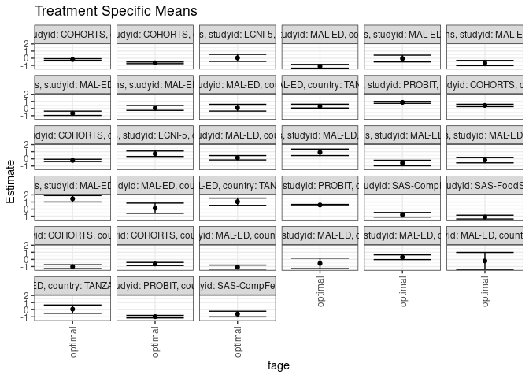

## Results Table

### Parameter: TSM

| agecat | studyid | country | intervention_level | baseline_level | estimate | ci_lower | ci_upper |
| --- | --- | --- | --- | --- | --- | --- | --- |
| Birth | COHORTS | GUATEMALA | optimal | observed | -1.0241843 | -1.2979158 | -0.7504528 |
| Birth | COHORTS | PHILIPPINES | optimal | observed | -0.6413211 | -0.8624691 | -0.4201731 |
| Birth | MAL-ED | BANGLADESH | optimal | observed | -1.0828867 | -1.3681550 | -0.7976185 |
| Birth | MAL-ED | INDIA | optimal | observed | -0.5595227 | -1.2981438 | 0.1790984 |
| Birth | MAL-ED | PERU | optimal | observed | 0.3047189 | -0.0260506 | 0.6354885 |
| Birth | MAL-ED | SOUTH AFRICA | optimal | observed | -0.2137998 | -1.4055986 | 0.9779990 |
| Birth | MAL-ED | TANZANIA, UNITED REPUBLIC OF | optimal | observed | 0.0745555 | -0.5036170 | 0.6527280 |
| Birth | PROBIT | BELARUS | optimal | observed | -0.9757622 | -1.1496604 | -0.8018640 |
| Birth | SAS-CompFeed | INDIA | optimal | observed | -0.6106352 | -1.0042511 | -0.2170194 |
| 6 months | COHORTS | GUATEMALA | optimal | observed | 0.4282875 | 0.2648106 | 0.5917644 |
| 6 months | COHORTS | PHILIPPINES | optimal | observed | -0.2204318 | -0.3810856 | -0.0597781 |
| 6 months | LCNI-5 | MALAWI | optimal | observed | 0.7114895 | 0.3277916 | 1.0951874 |
| 6 months | MAL-ED | BANGLADESH | optimal | observed | 0.1502472 | -0.1553137 | 0.4558080 |
| 6 months | MAL-ED | BRAZIL | optimal | observed | 0.9096936 | 0.4556395 | 1.3637476 |
| 6 months | MAL-ED | INDIA | optimal | observed | -0.5894165 | -0.9779238 | -0.2009092 |
| 6 months | MAL-ED | NEPAL | optimal | observed | -0.1781490 | -0.5642597 | 0.2079617 |
| 6 months | MAL-ED | PERU | optimal | observed | 1.4501962 | 1.0048034 | 1.8955890 |
| 6 months | MAL-ED | SOUTH AFRICA | optimal | observed | 0.1279971 | -0.5907595 | 0.8467536 |
| 6 months | MAL-ED | TANZANIA, UNITED REPUBLIC OF | optimal | observed | 1.0338608 | 0.5287696 | 1.5389521 |
| 6 months | PROBIT | BELARUS | optimal | observed | 0.5792854 | 0.5004550 | 0.6581157 |
| 6 months | SAS-CompFeed | INDIA | optimal | observed | -0.7994590 | -1.1245551 | -0.4743629 |
| 6 months | SAS-FoodSuppl | INDIA | optimal | observed | -1.1204216 | -1.3900710 | -0.8507722 |
| 24 months | COHORTS | GUATEMALA | optimal | observed | -0.1842895 | -0.3018073 | -0.0667717 |
| 24 months | COHORTS | PHILIPPINES | optimal | observed | -0.6494532 | -0.7648830 | -0.5340234 |
| 24 months | LCNI-5 | MALAWI | optimal | observed | 0.0513464 | -0.4448409 | 0.5475337 |
| 24 months | MAL-ED | BANGLADESH | optimal | observed | -1.1335389 | -1.3941222 | -0.8729557 |
| 24 months | MAL-ED | BRAZIL | optimal | observed | -0.0417747 | -0.5139432 | 0.4303938 |
| 24 months | MAL-ED | INDIA | optimal | observed | -0.6752214 | -1.0417741 | -0.3086687 |
| 24 months | MAL-ED | NEPAL | optimal | observed | -0.6692001 | -0.9675220 | -0.3708782 |
| 24 months | MAL-ED | PERU | optimal | observed | 0.0746816 | -0.2642773 | 0.4136405 |
| 24 months | MAL-ED | SOUTH AFRICA | optimal | observed | 0.1114050 | -0.3638221 | 0.5866321 |
| 24 months | MAL-ED | TANZANIA, UNITED REPUBLIC OF | optimal | observed | 0.3308962 | 0.0610614 | 0.6007310 |
| 24 months | PROBIT | BELARUS | optimal | observed | 0.8629891 | 0.7256854 | 1.0002929 |

### Parameter: E(Y)

| agecat | studyid | country | intervention_level | baseline_level | estimate | ci_lower | ci_upper |
| --- | --- | --- | --- | --- | --- | --- | --- |
| Birth | COHORTS | GUATEMALA | observed | observed | -1.0580408 | -1.1607065 | -0.9553751 |
| Birth | COHORTS | PHILIPPINES | observed | observed | -0.7309760 | -0.7780724 | -0.6838797 |
| Birth | MAL-ED | BANGLADESH | observed | observed | -1.0375000 | -1.2165024 | -0.8584976 |
| Birth | MAL-ED | INDIA | observed | observed | -0.9464000 | -1.3554144 | -0.5373856 |
| Birth | MAL-ED | PERU | observed | observed | 0.0529851 | -0.1628445 | 0.2688147 |
| Birth | MAL-ED | SOUTH AFRICA | observed | observed | -0.0073333 | -0.5181900 | 0.5035233 |
| Birth | MAL-ED | TANZANIA, UNITED REPUBLIC OF | observed | observed | 0.7115909 | 0.4034609 | 1.0197209 |
| Birth | PROBIT | BELARUS | observed | observed | -1.1436672 | -1.3543559 | -0.9329784 |
| Birth | SAS-CompFeed | INDIA | observed | observed | -0.6685468 | -0.8459689 | -0.4911247 |
| 6 months | COHORTS | GUATEMALA | observed | observed | 0.1925914 | 0.1205037 | 0.2646791 |
| 6 months | COHORTS | PHILIPPINES | observed | observed | -0.2878032 | -0.3296319 | -0.2459745 |
| 6 months | LCNI-5 | MALAWI | observed | observed | 0.5060377 | 0.3131397 | 0.6989358 |
| 6 months | MAL-ED | BANGLADESH | observed | observed | -0.1950111 | -0.3575506 | -0.0324716 |
| 6 months | MAL-ED | BRAZIL | observed | observed | 0.9365401 | 0.6541549 | 1.2189253 |
| 6 months | MAL-ED | INDIA | observed | observed | -0.7292288 | -0.8803893 | -0.5780683 |
| 6 months | MAL-ED | NEPAL | observed | observed | 0.1749789 | -0.0644624 | 0.4144202 |
| 6 months | MAL-ED | PERU | observed | observed | 1.0182129 | 0.7827641 | 1.2536616 |
| 6 months | MAL-ED | SOUTH AFRICA | observed | observed | 0.5158052 | 0.2517895 | 0.7798210 |
| 6 months | MAL-ED | TANZANIA, UNITED REPUBLIC OF | observed | observed | 0.5271500 | 0.3177522 | 0.7365478 |
| 6 months | PROBIT | BELARUS | observed | observed | 0.5731698 | 0.5135069 | 0.6328327 |
| 6 months | SAS-CompFeed | INDIA | observed | observed | -0.6641059 | -0.8040033 | -0.5242086 |
| 6 months | SAS-FoodSuppl | INDIA | observed | observed | -1.0121579 | -1.1280429 | -0.8962729 |
| 24 months | COHORTS | GUATEMALA | observed | observed | -0.2760853 | -0.3311930 | -0.2209775 |
| 24 months | COHORTS | PHILIPPINES | observed | observed | -0.6087584 | -0.6459824 | -0.5715345 |
| 24 months | LCNI-5 | MALAWI | observed | observed | -0.1979730 | -0.4244675 | 0.0285215 |
| 24 months | MAL-ED | BANGLADESH | observed | observed | -0.8844702 | -1.0263143 | -0.7426261 |
| 24 months | MAL-ED | BRAZIL | observed | observed | 0.5448101 | 0.2082313 | 0.8813890 |
| 24 months | MAL-ED | INDIA | observed | observed | -0.8968012 | -1.0287307 | -0.7648718 |
| 24 months | MAL-ED | NEPAL | observed | observed | -0.2794304 | -0.4767398 | -0.0821210 |
| 24 months | MAL-ED | PERU | observed | observed | 0.1198207 | -0.0845120 | 0.3241534 |
| 24 months | MAL-ED | SOUTH AFRICA | observed | observed | 0.4414045 | 0.2336389 | 0.6491701 |
| 24 months | MAL-ED | TANZANIA, UNITED REPUBLIC OF | observed | observed | 0.0766500 | -0.1115307 | 0.2648307 |
| 24 months | PROBIT | BELARUS | observed | observed | 0.6963019 | 0.5831245 | 0.8094793 |

### Parameter: PAR

| agecat | studyid | country | intervention_level | baseline_level | estimate | ci_lower | ci_upper |
| --- | --- | --- | --- | --- | --- | --- | --- |
| Birth | COHORTS | GUATEMALA | optimal | observed | -0.0338565 | -0.2813058 | 0.2135927 |
| Birth | COHORTS | PHILIPPINES | optimal | observed | -0.0896550 | -0.3058741 | 0.1265641 |
| Birth | MAL-ED | BANGLADESH | optimal | observed | 0.0453867 | -0.1884719 | 0.2792454 |
| Birth | MAL-ED | INDIA | optimal | observed | -0.3868773 | -1.0704347 | 0.2966801 |
| Birth | MAL-ED | PERU | optimal | observed | -0.2517339 | -0.5482405 | 0.0447728 |
| Birth | MAL-ED | SOUTH AFRICA | optimal | observed | 0.2064664 | -0.7367785 | 1.1497114 |
| Birth | MAL-ED | TANZANIA, UNITED REPUBLIC OF | optimal | observed | 0.6370354 | 0.1914650 | 1.0826059 |
| Birth | PROBIT | BELARUS | optimal | observed | -0.1679049 | -0.2918682 | -0.0439416 |
| Birth | SAS-CompFeed | INDIA | optimal | observed | -0.0579115 | -0.3358555 | 0.2200324 |
| 6 months | COHORTS | GUATEMALA | optimal | observed | -0.2356961 | -0.3869257 | -0.0844665 |
| 6 months | COHORTS | PHILIPPINES | optimal | observed | -0.0673714 | -0.2237369 | 0.0889941 |
| 6 months | LCNI-5 | MALAWI | optimal | observed | -0.2054518 | -0.5033880 | 0.0924844 |
| 6 months | MAL-ED | BANGLADESH | optimal | observed | -0.3452583 | -0.6374087 | -0.0531078 |
| 6 months | MAL-ED | BRAZIL | optimal | observed | 0.0268465 | -0.3402687 | 0.3939618 |
| 6 months | MAL-ED | INDIA | optimal | observed | -0.1398122 | -0.5060259 | 0.2264014 |
| 6 months | MAL-ED | NEPAL | optimal | observed | 0.3531279 | -0.0068904 | 0.7131462 |
| 6 months | MAL-ED | PERU | optimal | observed | -0.4319833 | -0.7742747 | -0.0896920 |
| 6 months | MAL-ED | SOUTH AFRICA | optimal | observed | 0.3878082 | -0.2372241 | 1.0128404 |
| 6 months | MAL-ED | TANZANIA, UNITED REPUBLIC OF | optimal | observed | -0.5067108 | -0.9499672 | -0.0634545 |
| 6 months | PROBIT | BELARUS | optimal | observed | -0.0061172 | -0.0717619 | 0.0595275 |
| 6 months | SAS-CompFeed | INDIA | optimal | observed | 0.1353530 | -0.1090793 | 0.3797854 |
| 6 months | SAS-FoodSuppl | INDIA | optimal | observed | 0.1082637 | -0.1405249 | 0.3570523 |
| 24 months | COHORTS | GUATEMALA | optimal | observed | -0.0917958 | -0.1996753 | 0.0160837 |
| 24 months | COHORTS | PHILIPPINES | optimal | observed | 0.0406948 | -0.0693391 | 0.1507286 |
| 24 months | LCNI-5 | MALAWI | optimal | observed | -0.2493194 | -0.6687984 | 0.1701597 |
| 24 months | MAL-ED | BANGLADESH | optimal | observed | 0.2490687 | 0.0317158 | 0.4664217 |
| 24 months | MAL-ED | BRAZIL | optimal | observed | 0.5865848 | 0.0917076 | 1.0814621 |
| 24 months | MAL-ED | INDIA | optimal | observed | -0.2215798 | -0.5706679 | 0.1275082 |
| 24 months | MAL-ED | NEPAL | optimal | observed | 0.3897697 | 0.1148703 | 0.6646692 |
| 24 months | MAL-ED | PERU | optimal | observed | 0.0451391 | -0.2469908 | 0.3372689 |
| 24 months | MAL-ED | SOUTH AFRICA | optimal | observed | 0.3299995 | -0.1487512 | 0.8087502 |
| 24 months | MAL-ED | TANZANIA, UNITED REPUBLIC OF | optimal | observed | -0.2542462 | -0.4551386 | -0.0533537 |
| 24 months | PROBIT | BELARUS | optimal | observed | -0.1666873 | -0.2916575 | -0.0417170 |